# Exam review Q4

Bi Cheng Wu

2021-03-16

Link to source. Note this source file is knitted using the [spin feature](https://bookdown.org/yihui/rmarkdown-cookbook/spin.html) of `knitr`.

## Background

After class, Karl invited me to tackle question 4 on the exam review. See recording [**here**](https://us-lti.bbcollab.com/recording/bb5cd70603a84654b5faa27a266fbbf2). This is the slightly more polished version than what I coded up live, with some fixes to the MC in MC part so you get a proper coverage estimate.

## Naive interval

First, we estimate the coverage of the naive interval. Define the naive confidence interval function according to [wiki](https://en.wikipedia.org/wiki/Mark_and_recapture#Confidence_interval)[^1]:

```r
# naive confidence interval
confint.recapture.exact = function(num.1st,num.2nd,num.2nd.tag,level = 0.95){
  k = num.2nd.tag
  K = num.2nd
  n = num.1st
  a2 = (1-level)/2
  k5 = k+0.5
  nk5 = n-k+0.5
  Kk5 = K-k+0.5
  sig = sqrt(1/k5+1/Kk5+1/nk5+k5/(nk5*Kk5))
  int = K+nk5-1+Kk5*nk5/k5*exp(c(1,-1)*qnorm(a2)*sig)
  names(int) = stats:::format.perc(c(a2,1-a2),3)
  return(int)
}
```

Now, there are two ways we can simulate this. We can either assume number of tagged fish roughly follows binomial distribution with `size=502` and `p=501/N` where `N` is our estimate of the population size (or equivalently `p=8/502`, since this is used to estimate `N`), **OR** we can sample two groups of fish of sizes `501` and `502` and count how many overlap.

We implement both below and compare their coverage.

```r
# compute estimate of N
N_est = 501*502/8

# method 1: use rbinom
sim.tag = function(){
  tagged = rbinom(1,size=502,p=501/N_est)
  return(tagged)
}

# method 2: use sample
sim.tag2 = function(){
  june_fish = sample.int(round(N_est),size=501)
  july_fish = sample.int(round(N_est),size=502)
  tagged = length(base::intersect(june_fish,july_fish))
  return(tagged)
}

# for each rep, compute naive interval for N and
# check if it contains our original N_est
check.naive.covered = function(num_tag){
  int = confint.recapture.exact(501,502,num_tag)
  if(N_est >= int[1] && N_est <= int[2]){
    return(TRUE)
  } else return(FALSE)
}
```

Now, we run both methods and compare their coverage.

```r
r = 10000
res = rep(NA,r)
for(i in 1:r){
  res[i] = check.naive.covered(sim.tag())
}
mean(res)
```

```
## [1] 0.9644
```

```r
res2 = rep(NA,r)
for(i in 1:r){
  res2[i] = check.naive.covered(sim.tag2())
}
mean(res2)
```

```
## [1] 0.9653
```

Their coverage seem to be pretty similar. Just for fun, let’s directly plot the output of the two simulation methods for comparison.

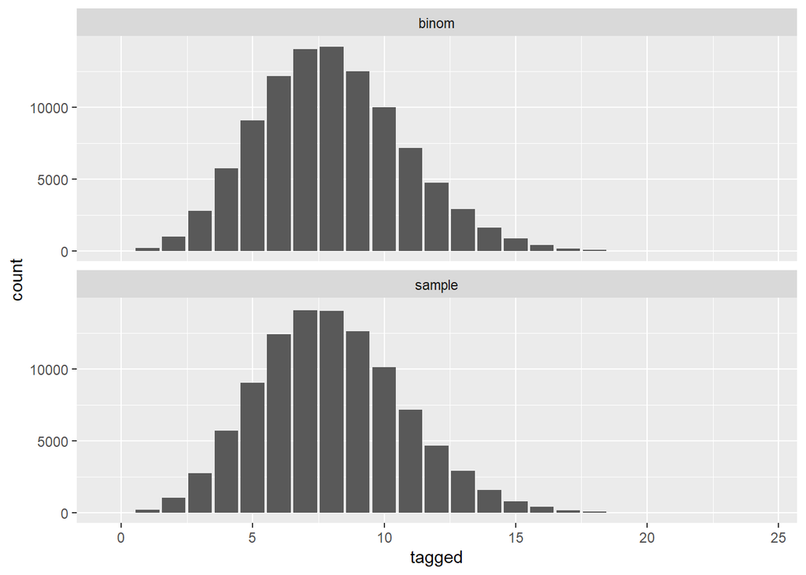

```r
library(tidyverse)
r = 100000
data.frame(method=gl(2,r,labels=c("binom","sample")),
           tagged=c(replicate(r,sim.tag()),replicate(r,sim.tag2()))) %>%
  ggplot(aes(x=tagged)) + facet_wrap(vars(method),ncol=1) + geom_bar()
```

The two methods give nearly identical results, so we don’t need to worry about which method we are using.

## MC interval

Next, we can estimate the coverage of the MC confidence intervals. Since we are using MC to both construct and test the interval, this is a little bit more complicated (you can see me struggle a little at the end of the recording).

I did eventually find and fix the bug (I was using the same `N_est` for each replicate of the experiment, instead of using a randomly generated estimate of `N`).

Since both sampling methods (`rbinom` used in `sim.tag` and `sample` using in `sim.tag2`) have been shown to be nearly identical, we will use the (probably) more efficient `rbinom` instead.

First we define a function that computes a SINGLE confidence interval using `r` MC replicates and checks if the “true” value of N is in the computed interval.

```r
# define function for checking coverage of a single MC interval
single.MC.covered = function(r,level=.95,num1=501,num2=502,tagged=8){

  # convert confidence level to half-area on either side
  # e.g. if level is 0.95, a2 is 0.025
  a2 = (1-level)/2

  # get "true" value of N
  N.est = num1*num2/tagged

  # define function to simulate number of tagged fish using rbinom,
  # then using that to compute a new simulated estimate of N
  sim.N = function(N) num1*num2/rbinom(1,size=num1,p=num1/N)

  # run sim.N to get 1 experiment where we assume the true value of N is
  # N.est, and we go out in July and catch 502 fish, and use our tagged count
  # to produce a single estimate of what we THINK N is
  # (note in this experiment, we don't know the real N is N.est, we just know
  # we THINK N is roughly N.sim)
  N.sim = sim.N(N.est)

  # using our N.sim, we RERUN sim.N r times to get a MC confidence interval
  # around out N.sim, using a2 and 1-a2 as the lower and upper quantiles
  ci = quantile(replicate(r,sim.N(N.sim)),c(a2,1-a2))

  # return TRUE if CI contains the true value N.est, or FALSE otherwise
  return(N.est>=ci[1] && N.est<=ci[2])
}
```

Hopefully that wasn’t too confusing. Let’s check the coverage of this MC interval. For fun, let’s again do a low rep and high rep and compare them. Note the difference below between `r` and `n`. `r` is the **number of reps used to construct** the MC interval, whereas `n` is the **number of times we test these intervals**. For low/high reps, we let `r=100` vs `r=1000` to see if using more reps gives better coverage. To estimate this coverage, we use the same `n=1000` for both.

```r
# get coverage of low r
mean(
  replicate(n=1000,single.MC.covered(r=100))
)
```

```
## [1] 0.928
```

```r
# get coverage of high r
mean(
  replicate(n=1000,single.MC.covered(r=1000))
)
```

```
## [1] 0.953
```

It seems like the high `r` intervals are more reliable. If we are **REALLY** crazy, we can go **ONE LEVEL DEEPER** and repeat the above chunk many times to see how variable the coverage of each interval is. This is getting super meta, since we’re using MC to determine the variability of the MC-estimated coverage of an MC-computed interval. This is starting to reach the computational limits of my single machine, so I’m just setting `n=200` in the coverage computation and only use 200 coverage computations to find the variability, but it should be enough to give us an idea of the variability of each coverage.

I’m also going to throw in the naive interval for comparison, so we can see whether or not it’s on par with the MC intervals.

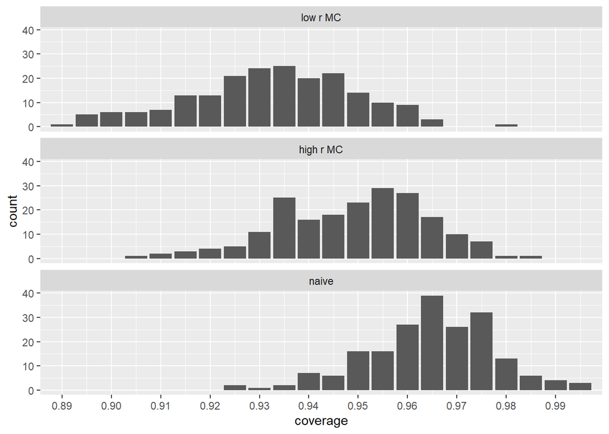

```r
df.var = data.frame(
  method = gl(3,200,labels=c("low r MC","high r MC",'naive')),
  coverage = c(
    # get low-r coverages
    replicate(
      200,
      mean(
        replicate(n=200,single.MC.covered(r=100))
      )
    ),
    # get high-r coverages
    replicate(
      200,
      mean(
        replicate(n=200,single.MC.covered(r=1000))
      )
    ),
    replicate(
      200,
      mean(
        replicate(n=200,check.naive.covered(sim.tag()))
      )
    )
  )
)
ggplot(df.var,aes(x=coverage)) + facet_wrap(vars(method),ncol=1) + geom_bar() +
  scale_x_continuous(expand=c(.02,0),
                     breaks=seq(min(df.var$coverage),max(df.var$coverage),by=.01))
```

As you can see, the low-r 95% MC confidence interval sometimes achieves the desired level of 95% coverage, but it often falls short. However, a high-r 95% MC confidence interval much more often achieves the desired 95% coverage.

Surprisingly, the naive interval is able to achieve even better coverage than both the MC methods. We can quickly compute what proportion of the resulting coverages are at least 95%.

```r
df.var %>%
  group_by(method) %>%
  summarize(">= 0.95" = mean(coverage >= 0.95), .groups="drop")
```

```
## # A tibble: 3 x 2
##   method    `>= 0.95`
##   <fct>         <dbl>
## 1 low r MC      0.185
## 2 high r MC     0.575
## 3 naive         0.91
```

Our results tell us that roughly speaking, for this problem, low-r MC intervals give us about 19% chance of having >= 95% coverage, high-r MC intervals give us about 58% chance of having >= 95% coverage, and naive intervals give us about 91% chance of having >= 95% coverage.

[^1]: See [Sadinle (2009)](https://doi.org/10.1080/03610910903168595) for details.